# OLET5602 Final Project: Transcription factor target gene prediction through multi-omics datasets

Trent Henderson, Shivanjali Ratnaseelan, Ethan Chang, Henry Howard, Preethom Pal

2022-08-27

# 1 Background and purpose

Transcriptional regulation orchestrates gene activity through the regulation of the DNA to RNA conversion process. This form of regulation is crucial to all living organisms. It is organised by transcription factors, who, along with other factors, in concert drive mRNA expression for an organism. These processes have wide-reaching, important implications, as distinct transcriptional networks drive development, lineage specification, and cell fate decisions during early embryonic development (Theunissen and Jaenisch 2017). Recent advances in -omics technologies have made it possible to profile genome-wide transcriptional and epigenetic events for investigating transcriptional networks. As a result, a key goal of modern computational -omics work is to identify the target genes of transcription factors that drive key transcriptional events over a course of time. This report seeks to extend this goal by constructing a classification pipeline which uses -omics information (transcriptomics, proteomics, and epigenomics) to predict whether a target gene belongs to two important transcription factors (or not): SOX2 and NANOG. SOX2 is a key transcription factor for maintaining pluripotency (a cell’s ability to differentiate into other cell types) of undifferentiated embryonic stem cells. NANOG also helps embryonic stem cells maintain pluripotency, but does so through the suppression of cell determination factors.

The following code excerpt loads the dataset and the relevant R packages to reproduce the work presented here (see end of the report for a full session information print out):

```r
# Read in data and load R packages

load("Final_Project_ESC.RData", verbose = TRUE)
```

```
## Loading objects:
##   Transcriptome
##   Proteome
##   H3K4me3
##   H3K27me3
##   PolII
##   H3K4me1
##   H3K27ac
##   H3K9me2
##   cMyc_target_genes
##   cMyc_target_genes_subset
##   OSN_target_genes
##   OSN_target_genes_subset
```

```r
library(tibble)
library(dplyr)
library(tidyr)
library(purrr)
library(ggplot2)
library(ggrepel)
library(GGally)
library(patchwork)
library(broom)
library(factoextra)
library(caret)
```

# 2 Exploratory data analysis

Exploratory data analysis was performed to understand the three datasets avilable to us: (i) transcriptome; (ii) proteome; and (iii) epigenome (of which there are six separate histone mark datasets). The purpose of this analysis was to understand the role of the time-course differentiation variables across each data type, as these variables will be used to train classification algorithms later in this paper. We will explore each of the datasets in turn.

## 2.1 Transcriptome

The transcriptome dataset contains $19,788$ unique genes, each sampled across 8 timepoints: 0hr (stem cells prior to differentiation stimulation), 1hr, 6hr, 12hr, 24hr, 36hr, 48hr, and 72hr. Figure 2.1 below plots univariate and pairwise statistics for each time-course differentiation variable in the dataset. From a univariate perspective, we see roughly leptykurtic Gaussian distributions of values, except for the `0hr` timepoint, where we see smaller peaks symmetrically on either side of the mode. From a pairwise perspective, apart from all relationships involving `0hr`, we see roughly positive linear relationships, with the linearity becoming stronger between later timepoints. Notably, the pairwise relationships between `0hr` and all other timepoints appear discretised, and `1hr` and all other timepoints are positive linear but with heteroskedasticity.

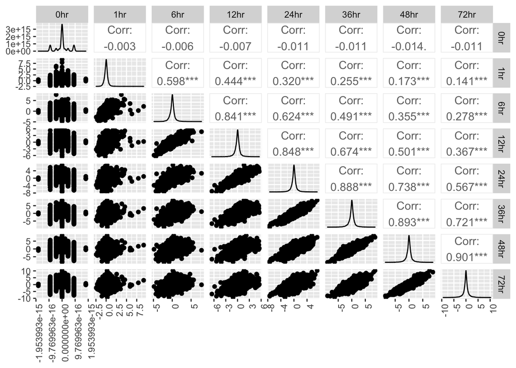

Figure 2.1: Univariate and pairwise statistics of each time-course differentiation in the transcriptome dataset.

```r
ggpairs(as.data.frame(Transcriptome)) +
  theme(axis.text.x = element_text(angle = 90, hjust = 1))
```

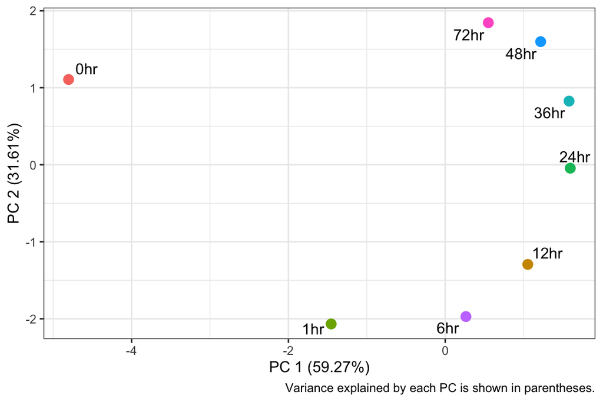

Figure 2.2: Low dimensional projection of transcriptome time-course differentation using PCA.

```r
#' Function to calculate PCA and return useful outputs for an input matrix
#' @param matrix the input data matrix
#' @param subtitle string for the plot subtitle. Defaults to \code{NULL} for no subtitle
#' @return an object of class \code{list}
#'

do_pca <- function(matrix, subtitle = NULL){

  # Fit PCA on correlation matrix

  cors <- cor(matrix)
  fits <- stats::prcomp(cors, scale = TRUE)

  # Retrieve eigenvalues and tidy up variance explained for first 2 PCs for plotting

  eigens <- fits %>%
    tidy(matrix = "eigenvalues") %>%
    filter(PC %in% c(1, 2)) %>% # Filter to just the 2 going in the plot
    select(c(PC, percent)) %>%
    mutate(percent = paste0("(", round(percent * 100, digits = 2), "%)")) # Make nice format

  # Draw plot

  p <- fits %>%
    augment(cors) %>%
    mutate(.rownames = as.factor(.rownames),
           .rownames = gsub(".*_", "\\1", .rownames)) %>%
    ggplot(aes(x = .fittedPC1, y = .fittedPC2)) +
    geom_point(size = 3, ggplot2::aes(colour = .rownames)) +
    geom_text_repel(aes(label = .rownames)) +
    labs(x = paste0("PC 1 ", eigens$percent[1]),
         y = paste0("PC 2 ", eigens$percent[2]),
         caption = "Variance explained by each PC is shown in parentheses.") +
    scale_fill_brewer(palette = "Dark2") +
    theme_bw() +
    theme(legend.position = "none")

  if(!is.null(subtitle)){
    p <- p +
      labs(subtitle = subtitle,
           caption = NULL)
  }

  mylist <- list(fits, p)
  names(mylist) <- c("fits", "p")
  return(mylist)
}

# Run function

transcriptome_pca <- do_pca(matrix = Transcriptome)
print(transcriptome_pca$p)
```

## 2.2 Proteome

To first understand this dataset, we plotted the univariate and pairwise statistics (shown in Figure 2.3). Again, from a univariate perspective, we see roughly leptykurtic Gaussian distributions of values. From a pairwise perspective, we see roughly positive linear relationships with heteroskedasticity, with the linearity becoming stronger between later timepoints.

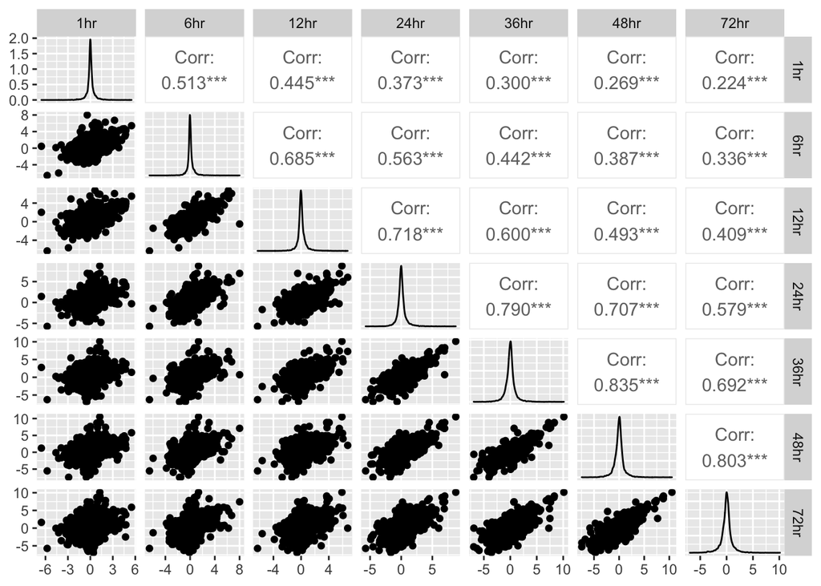

Figure 2.3: Univariate and pairwise statistics of each time-course differentiation in the proteome dataset.

```r
ggpairs(as.data.frame(Proteome))
```

Applying the function defined earlier for the transcriptome case, but with the proteome input data, we can again in Figure 2.4 below see a clear anti-clockwise trajectory of increasing time, with each positioned in its own region of space along this pattern. We also find that the first principal component (PC) explains a similarly large percentage of the variance in the correlation matrix data ($61.31\%$), while the second PC explains $26.44\%$, for a combined total of $87.75\%$ — another strong result for just two PCs. This, again, suggests that the dimensionality of the proteome dataset could be reduced using PCs.

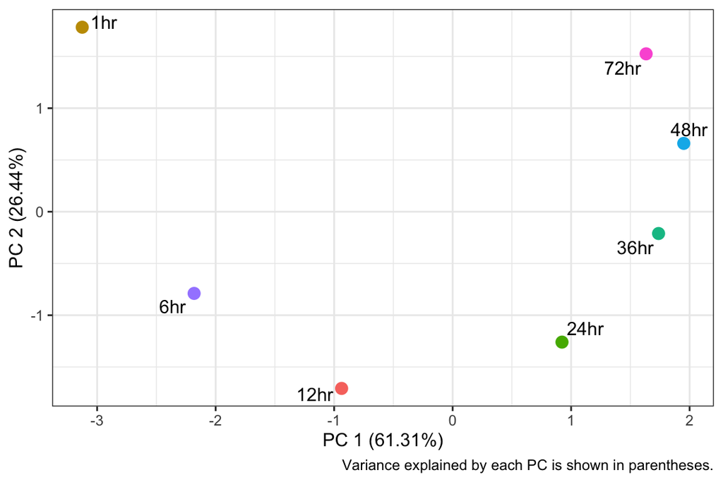

Figure 2.4: Low dimensional projection of proteome time-course differentation using PCA.

```r
proteome_pca <- do_pca(matrix = Proteome)
print(proteome_pca$p)
```

Evidently, time courses across both transcriptomic and proteomic structures appear to be differentiated in a low dimensional space of the first two PCs. However, it remains unclear whether each PC is driven by one or more time courses. Examining the variable loadings for the PCA can reveal this information, which is plotted below in Figure 2.5. Here, we see for both transcriptome and proteome, that multiple variables (i.e., time courses) contribute meaningfully to each principal component — especially the first two which are of primary interest to us. This means that if further analysis uses PCs as inputs instead of the raw time course data, any model would not simply be learning on time courses that loaded singularly onto each PC. However, we do see that very strong loadings exist for the 48hr time course onto the second-last PCs in both cases (PC 7 for transcriptome and PC 6 for proteome), which is interesting. Further, we see the earliest (0hr for transcriptome, 1hr for proteome) and latest (72hr for both datasets) time courses exhibit very strong loading onto the final PC in both cases — which potentially highlights the heterogeneity of these two time points relative to the rest.

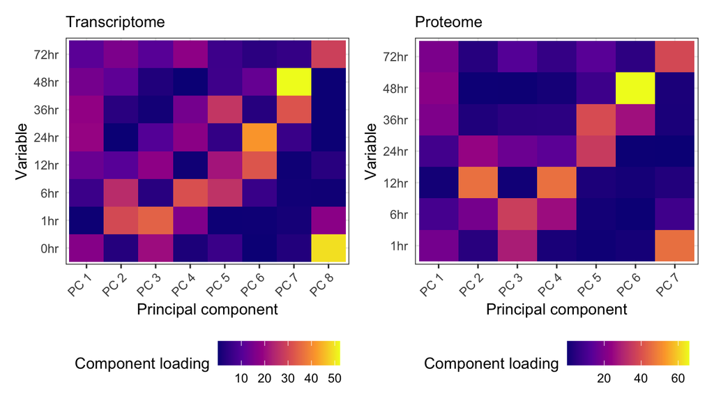

Figure 2.5: Variable loadings onto principal components for transcriptome and proteome datasets.

```r
#' Function to plot factor loadings for PCA
#' @param pca the model output object from \code{prcomp}
#' @param subtitle string specifying the subtitle of the plot
#' @return object of class \code{ggplot}
#'

plot_loadings <- function(pca, subtitle){

  # Extract variable loadings

  contribs <- get_pca_var(pca)
  loadings_plot <- as.data.frame(contribs$contrib)
  n_vars <- ncol(loadings_plot)

  # Generate labels for plot programmatically

  fac_levs <- rep(NA, length.out = n_vars)

  for(i in 1:n_vars){
    fac_levs[i] <- paste0("PC ", i)
  }

  time_levs <- rownames(loadings_plot)

  # Draw plot

  loadings_plot <- loadings_plot %>%
    rownames_to_column(var = "timepoint") %>%
    pivot_longer(cols = 2:(n_vars + 1), names_to = "names", values_to = "value") %>%
    mutate(names = gsub("Dim.", "PC ", names)) %>%
    mutate(names = factor(names, levels = fac_levs),
           timepoint = factor(timepoint, levels = time_levs)) %>%
    ggplot(aes(x = names, y = timepoint, fill = value))  +
    geom_tile() +
    labs(subtitle = subtitle,
         x = "Principal component",
         y = "Variable",
         fill = "Component loading") +
    scale_fill_viridis_c(option = "plasma") +
    theme_bw() +
    theme(axis.text.x = element_text(angle = 45, hjust = 1),
          axis.ticks.y = element_blank(),
          legend.position = "bottom",
          panel.grid.minor = element_blank())

  return(loadings_plot)
}

# Use functions to draw plots

transcriptome_load <- plot_loadings(pca = transcriptome_pca$fits, subtitle = "Transcriptome")
proteome_load <- plot_loadings(pca = proteome_pca$fits, subtitle = "Proteome")
patchwork::wrap_plots(transcriptome_load, proteome_load, ncol = 2, nrow = 1)
```

## 2.3 Epigenome

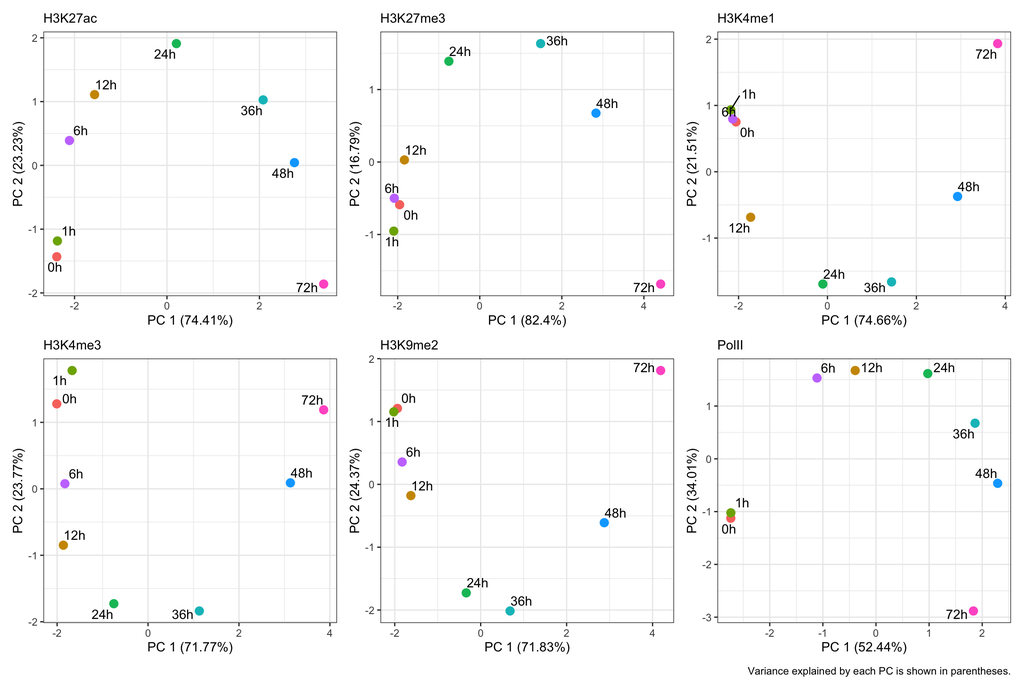

Figure 2.6: Low dimensional projection of epigenome time-course differentation using PCA.

```r
epigenome_list <- list(H3K27ac, H3K27me3, H3K4me1, H3K4me3, H3K9me2, PolII)
epi_names <- c("H3K27ac", "H3K27me3", "H3K4me1", "H3K4me3", "H3K9me2", "PolII")
names(epigenome_list) <- epi_names
epigenomes <- purrr::map2(.x = epigenome_list, .y = epi_names, ~ do_pca(matrix = .x, subtitle = .y))
plots <- list(epigenomes$H3K27ac$p, epigenomes$H3K27me3$p, epigenomes$H3K4me1$p, epigenomes$H3K4me3$p, epigenomes$H3K9me2$p, epigenomes$PolII$p)

patchwork::wrap_plots(plots, ncol = 3, nrow = 2) +
  patchwork::plot_annotation(caption = "Variance explained by each PC is shown in parentheses.")
```

We can similarly explore the variable loadings for the PCA models for the epigenome data. In Figure 2.7 below, we see that across the six histone marks, the first two PCs are typically characterised by loadings from multiple time course variables — suggesting their suitability as inputs for modelling. However, we do also see that very strong loadings of a single time course onto a range of PCs are visible, such as for H3K4me1, where 24hr loads strongly onto PC 2, 0hr onto PC 4, 1hr onto PC 7, and 72 hr onto PC 8.

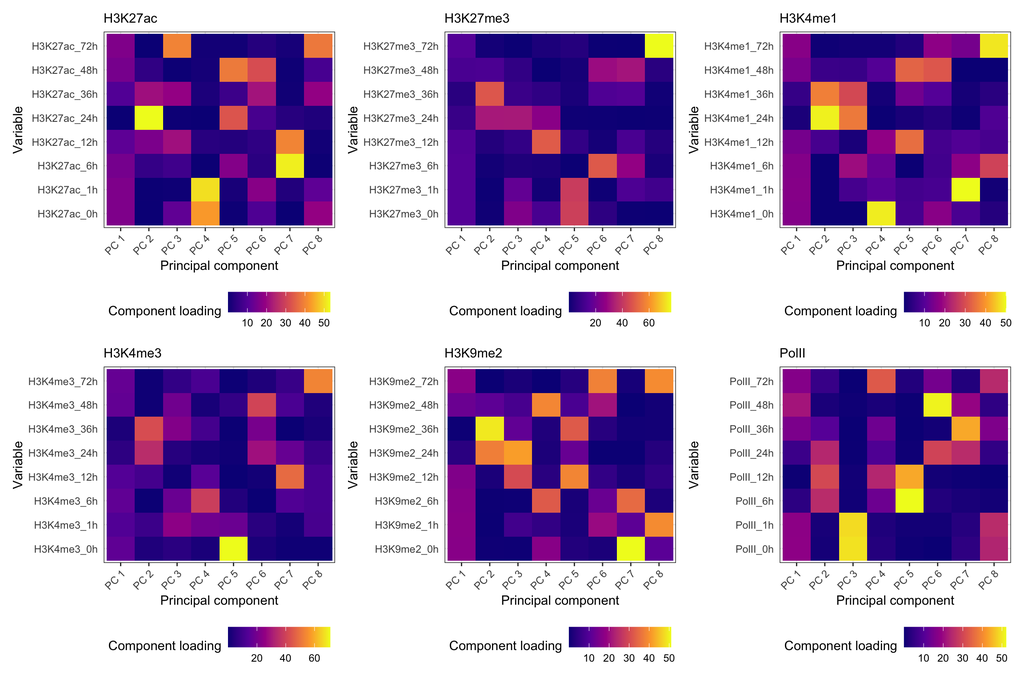

Figure 2.7: Variable loadings onto principal components for epigenome datasets across six histone marks.

```r
epigenome_pc_list <- list(epigenomes$H3K27ac$fits, epigenomes$H3K27me3$fits, epigenomes$H3K4me1$fits,
                          epigenomes$H3K4me3$fits, epigenomes$H3K9me2$fits, epigenomes$PolII$fits)

names(epigenome_list) <- epi_names
epigenome_loads <- purrr::map2(.x = epigenome_pc_list, .y = epi_names, ~ plot_loadings(pca = .x, subtitle = .y))
patchwork::wrap_plots(epigenome_loads, ncol = 3, nrow = 2)
```

## 2.4 Construction of combined dataset

Prior work transformed both the transcriptome and proteome datasets to be in a comparable scale — meaning they can be easily appended to form a combined dataset. We can combine the two based on only the consistent genes across both datasets:

```r
Proteome2 <- as.data.frame(Proteome)
colnames(Proteome2) <- paste0("p_", colnames(Proteome2))
Proteome2 <- rownames_to_column(.data = Proteome2, var = "gene")
Transcriptome2 <- as.data.frame(Transcriptome)
colnames(Transcriptome2) <- paste0("t_", colnames(Transcriptome2))
Transcriptome2 <- rownames_to_column(.data = Transcriptome2, var = "gene")

prot_trans_df <- Proteome2 %>%
  inner_join(Transcriptome2, by = c("gene" = "gene")) %>% # Ensures we retain only common genes
  mutate(label = ifelse(gene %in% OSN_target_genes_subset, "OSN", "Other"),
         label = as.factor(label))
```

However, it is noted that there is a substantial imbalance between the classes, with $N = 95$ OSN genes and $N = 8260$ Other genes. To understand the relative positioning of all these genes in an interpretable space, we reduced the dimensionality of this concatenated dataset from 15 variables down to 2 using principal components analysis. Figure 2.8 below visualises the genes in this low dimensional projection, with OSN genes coloured red and Other genes coloured green. A $99\%$ covariance ellipsoid was calculated from the multivariate normal distribution of the first two PCs for the OSN genes to visualise the number of Other genes that can be considered *least similar* to OSN genes in this space.

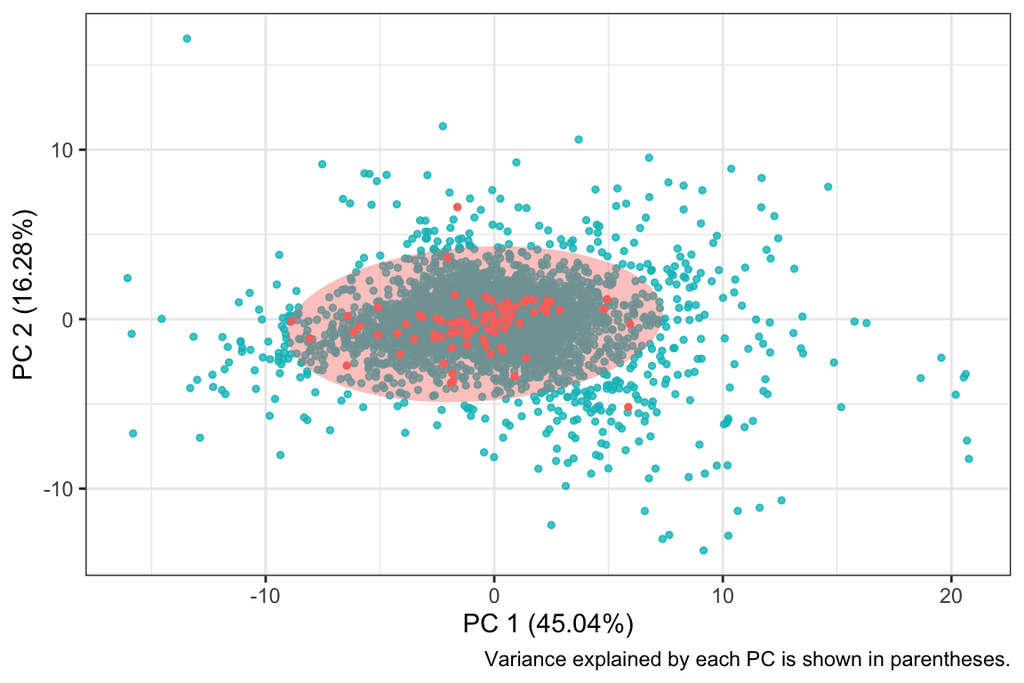

Figure 2.8: Low dimensional projection of transcriptome and proteome time-course differentation using PCA by class, with OSN genes coloured in red (with covariance ellipse) and other genes coloured in green.

```r
# Visualise genes from both classes in low dimensional space

osn_pca <- stats::prcomp(prot_trans_df[, 2:16], scale = TRUE)

osn_pca_df <- osn_pca %>%
  augment(as.data.frame(prot_trans_df[, 2:16])) %>%
  dplyr::select(c(.fittedPC1:.fittedPC15)) %>%
  mutate(gene = prot_trans_df$gene,
         label = prot_trans_df$label)

osn_pca_eigens <- osn_pca %>%
  tidy(matrix = "eigenvalues") %>%
  filter(PC %in% c(1, 2)) %>% # Filter to just the 2 going in the plot
  select(c(PC, percent)) %>%
  mutate(percent = paste0("(", round(percent * 100, digits = 2), "%)")) # Make nice format

osn_pca_plot <- osn_pca_df %>%
  ggplot(aes(x = .fittedPC1, y = .fittedPC2)) +
  geom_point(data = subset(osn_pca_df, label == "Other"), size = 1, alpha = 0.8, colour = "#00BFC4") +
  stat_ellipse(data = subset(osn_pca_df, label == "OSN"), type = "norm", level = 0.99, geom = "polygon", alpha = 0.4, fill = "#F8766D") +
  geom_point(data = subset(osn_pca_df, label == "OSN"), size = 1, colour = "#F8766D") +
  labs(x = paste0("PC 1 ", osn_pca_eigens$percent[1]),
       y = paste0("PC 2 ", osn_pca_eigens$percent[2]),
       caption = "Variance explained by each PC is shown in parentheses.") +
  scale_fill_brewer(palette = "Dark2") +
  theme_bw() +
  theme(legend.position = "bottom")

print(osn_pca_plot)
```

Guided by the low dimensional projection presented in Figure 2.8, we can reduce the class imbalance in the data through statistical selection of a sample of “Other” genes that are ‘least like’ the OSN genes from which we can construct a classification algorithm. The heuristic for this paper is that we will retain only those Other genes which lie outside the $99\%$ multivariate normal distribution covariance ellipse of the OSN genes in the two-dimensional space of $PC1$ and $PC2$. The below code finds these genes and highlights them in the space, as plotted in Figure 2.9. This reduces the sample size of Other genes from $8260$ to $389$, which represents a shift in ratio of $OSN:Other$ genes of $95:8260$ to $95:389$ which is much more appropriate for statistical modelling.

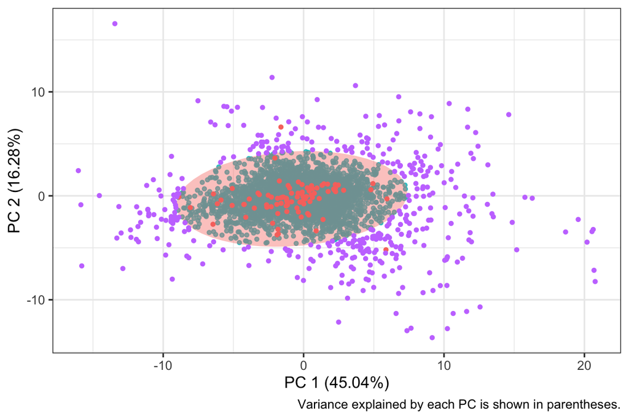

Figure 2.9: Low dimensional projection of transcriptome and proteome time-course differentation using PCA by class, with OSN genes coloured in red (with covariance ellipse), other genes coloured in green, and the subset of other genes that are least like OSN genes as determined by positioning outside the covariance ellipse are coloured in purple.

```r
# Find "Other" genes which lie outside the 99% covariance ellipse of the OSN genes

coords <- ggplot_build(osn_pca_plot)$data
points <- coords[[1]]
ell <- coords[[2]]

other <- data.frame(points[1:2],
                    in.ell = as.logical(sp::point.in.polygon(points$x, points$y, ell$x, ell$y))) %>%
  mutate(gene = subset(osn_pca_df, label == "Other")$gene) %>%
  filter(!in.ell) %>%
  pull(gene) # Retain "Other" genes that lie outside the covariance ellipse

# Subset original proteome/transcriptome dataset

prot_trans_df <- prot_trans_df %>%
  filter(gene %in% append(prot_trans_df[prot_trans_df$label == "OSN", 1], other))

# Filter and re-draw plot

osn_pca_plot_hl <- osn_pca_df %>%
  mutate(label = ifelse(label == "Other" & gene %in% other, "Subset", as.character(label)))

osn_pca_plot_hl <- osn_pca_plot_hl %>%
  ggplot(aes(x = .fittedPC1, y = .fittedPC2)) +
  geom_point(data = subset(osn_pca_plot_hl, label == "Other"), size = 1, alpha = 0.8, colour = "#00BFC4") +
  stat_ellipse(data = subset(osn_pca_plot_hl, label == "OSN"), type = "norm", level = 0.99, geom = "polygon", alpha = 0.4, fill = "#F8766D") +
  geom_point(data = subset(osn_pca_plot_hl, label == "OSN"), size = 1, colour = "#F8766D") +
  geom_point(data = subset(osn_pca_plot_hl, label == "Subset"), size = 1, colour = "#C77CFF") +
  labs(x = paste0("PC 1 ", osn_pca_eigens$percent[1]),
       y = paste0("PC 2 ", osn_pca_eigens$percent[2]),
       caption = "Variance explained by each PC is shown in parentheses.") +
  scale_fill_brewer(palette = "Dark2") +
  theme_bw() +
  theme(legend.position = "bottom")

print(osn_pca_plot_hl)
```

Preparation of the epigenome datasets according to the filtering of Other genes was also performed separately for each of the six histone marks:

```r
#' Function to prepare histone mark data for modelling
#' @param X the data matrix
#' @param cm \code{Boolean} whether to label based on subset (for training) or not (for predictive evaluation). Defaults to \code{FALSE}
#' @return an object of class \code{data.frame}
#'

prepare_histone_df <- function(X, cm = FALSE){

  X1 <- as.data.frame(X) %>%
  tibble::rownames_to_column(var = "gene")

  if(cm){
    X1 <- X1 %>%
      mutate(label = ifelse(gene %in% OSN_target_genes_subset, "OSN", "Other"),
             label = as.factor(label)) %>%
      filter(gene %in% append(prot_trans_df2[prot_trans_df2$label == "OSN", 1], other))
  } else{
    X1 <- X1 %>%
      mutate(label = ifelse(gene %in% OSN_target_genes, "OSN", "Other"),
             label = as.factor(label)) %>%
      filter(gene %in% append(prot_trans_df[prot_trans_df$label == "OSN", 1], other))
  }

  return(X1)
}

H3K27ac_df <- prepare_histone_df(H3K27ac)
H3K27me3_df <- prepare_histone_df(H3K27me3)
H3K4me1_df <- prepare_histone_df(H3K4me1)
H3K4me3_df <- prepare_histone_df(H3K4me3)
H3K9me2_df <- prepare_histone_df(H3K9me2)
PolII_df <- prepare_histone_df(PolII)
```

## 2.5 Gene classification

Following exploratory data analysis, a set of seven predictive models for identifying gene membership to the two transcription factors of interest (SOX2 and NANOG) or not was constructed (one model for each dataset — the combined proteome/transcriptome dataset and the six individual histone marks). The type of classification model that was chosen is a Gaussian process (GP) with an exponentiated-quadratic kernel/covariance function (also known as a “radial basis function” or “squared exponential”). Recall that a Gaussian distribution is parameterised by two scalar values: (i) mean $\mu$; and (ii) variance $\sigma^{2}$ (or the standard deviation which is the square root of the variance). We can write it as $\mathcal{N}(\mu, \sigma^{2})$. We can increase the dimensionality of this univariate case to describe *multivariate Gaussian distributions*, by increasing the dimensionality of the parameters. This results in the mean becoming a *mean vector* $\mu$ and the variance becoming a *covariance matrix* $\Sigma$ (as we now need to describe both the variance of each variable and the covariance between them), written as $\textbf{X} \sim \mathcal{N}(\mu, \Sigma)$. A GP is a generalisation of this idea to an infinite number of dimensions. This means the mean vector and covariance matrix now become a *mean function* $m(x)$ and *covariance function* $k(x, x')$ (also called a “kernel”). Putting this together, we can define a GP as:

$$f(x) = \mathcal{GP}(m(x), k(x, x'))$$

The most common covariance function is the exponentiated-quadratic, which we apply here. This function forms the basis for simpler kernel-based machine learning techniques, such as support vector machines. One of the reasons for its popularity is that it looks quite similar to the formula for a univariate Gaussian distribution. It is mathematically defined as:

where where $\sigma^{2}$ is the variance (average distance of a function away from its mean) and $\mathcal{l}$ is the lengthscale (the length of the “wiggles” in a function). These are *hyperparameters* that can be set or learnt to control the shape of the kernel. To implement this model in R, we make use of the `caret` package for machine learning which enables usage of an RBF GP through the model labelled `"gaussprRadial"`. Below, we define a function for training such a model using $10$-fold cross-validation, and run it for each of the seven datasets separately.

```r
#' Do 10-fold CV to train a machine learning model
#' @param data \code{data.frame} of input data
#' @param model string of the \code{caret} model to use. Defaults to \code{"gaussprRadial"}
#' @param seed fix R's pseudo-random number generator for reproducibility. Defaults to \code{123}
#' @return object of class \code{list} containing \code{caret} model information
#'

fit_model <- function(data, model = "gaussprRadial", seed = 123){

  set.seed(seed)

  # Remove "gene" column as it will mess with model

  data2 <- data %>%
    dplyr::select(-c(gene))

  # Fit model

  fit <- caret::train(label ~ .,
                      data = data2,
                      method = model,
                      trControl = caret::trainControl(method = "cv", number = 10, classProbs = TRUE),
                      preProcess = c("center", "scale"),
                      summaryFunction = twoClassSummary)

  return(fit)
}

# Run the function for all datasets

models <- list()
model_dfs <- list(prot_trans_df, H3K27ac_df, H3K27me3_df, H3K4me1_df, H3K4me3_df, H3K9me2_df, PolII_df)

for(i in 1:length(model_dfs)){
  themod <- fit_model(data = model_dfs[[i]], model = "gaussprRadial", seed = 123)
  models[[i]] <- themod
}

names(models) <- c("prot_trans_df", "H3K27ac_df", "H3K27me3_df", "H3K4me1_df", "H3K4me3_df", "H3K9me2_df", "PolII_df")
```

### 2.5.1 Comparison to benchmark results

With the seven models now trained, we move to comparing predictive performance against benchmarks. The major comparison is the performance of each model in predicting gene class membership of the whole list of OSN target genes and not just the subset which formed the basis of the data to train each model. Performance can be quantified through different metrics obtained via calculations on the confusion matrix — a matrix which cross-tabulates frequencies of model predictions against the actual class labels. The confusion matrix (for a two-class problem) returns four potential mutually-exclusive, collectively-exhaustive values: (i) true positive (TP); (ii) false positive (FP); (iii) false negative (FN); and (iv) true negative (TN). We summarise each model’s predictive performance of the full gene set using four metrics calculated from the confusion matrix:

1. Accuracy $= \frac{\text{TP} + \text{TN}}{\text{TP} + \text{FP} + \text{FN} + \text{TN}}$
2. Sensitivity $= \frac{\text{TP}}{\text{TP} + \text{FN}}$
3. Specificity $= \frac{TN}{\text{FP} + \text{TN}}$
4. Balanced Accuracy $= \frac{\text{sensitivity} + \text{specificity}}{2}$

The code below produces Table 2.1, which compares each model on these performance metrics.

```r
# Prepare evaluation datasets

prot_trans_df2 <- Proteome2 %>%
  inner_join(Transcriptome2, by = c("gene" = "gene")) %>% # Ensures we retain only common genes
  mutate(label = ifelse(gene %in% OSN_target_genes, "OSN", "Other"),
         label = as.factor(label))

prot_trans_df2 <- prot_trans_df2 %>%
  filter(gene %in% append(prot_trans_df2[prot_trans_df2$label == "OSN", 1], other))

H3K27ac_df2 <- prepare_histone_df(H3K27ac, cm = TRUE)
H3K27me3_df2 <- prepare_histone_df(H3K27me3, cm = TRUE)
H3K4me1_df2 <- prepare_histone_df(H3K4me1, cm = TRUE)
H3K4me3_df2 <- prepare_histone_df(H3K4me3, cm = TRUE)
H3K9me2_df2 <- prepare_histone_df(H3K9me2, cm = TRUE)
PolII_df2 <- prepare_histone_df(PolII, cm = TRUE)
eval_dfs <- list(prot_trans_df2, H3K27ac_df2, H3K27me3_df2, H3K4me1_df2, H3K4me3_df2, H3K9me2_df2, PolII_df2)

# Compute performance metrics for each model/dataset

metrics <- list()

for(i in 1:length(models)){

  pred_data <- eval_dfs[[i]] %>% dplyr::select(-c(gene)) # Remove gene column to avoid model errors
  pred <- predict(models[[i]], newdata = pred_data, type = "prob") # Generate predictions
  pred <- pred %>% mutate(predicted_label = ifelse(pred[1] > pred[2], colnames(pred)[1], colnames(pred)[2]))
  pred_data <- pred_data %>% mutate(predicted_label = as.factor(pred$predicted_label))
  cm <- caret::confusionMatrix(pred_data$predicted_label, pred_data$label) # Confusion matrix

  results <- data.frame(Model = ifelse(i == 1, "Proteome + Transcriptome", paste0("Epigenome (", gsub("_df", "\\1", names(models)[i]), ")")),
                        Accuracy = round(cm$overall[1], digits = 3),
                        `Balanced Accuracy` = round(cm$byClass[11], digits = 3),
                        Sensitivity = round(cm$byClass[1], digits = 3),
                        Specificity = round(cm$byClass[2], digits = 3)) # Summarise performance

  metrics[[i]] <- results
}

# Bind results and present table

all_metrics <- do.call(rbind, metrics) %>% arrange(-Accuracy)
rownames(all_metrics) <- NULL
knitr::kable(all_metrics, caption = "Summary of predictive performance of all models.")
```

Table 2.1: Summary of predictive performance of all models.

| Model | Accuracy | Balanced.Accuracy | Sensitivity | Specificity |
| --- | --- | --- | --- | --- |
| Proteome + Transcriptome | 0.913 | 0.908 | 0.822 | 0.995 |
| Epigenome (H3K9me2) | 0.863 | 0.544 | 0.105 | 0.983 |
| Epigenome (H3K4me1) | 0.803 | 0.585 | 0.284 | 0.886 |
| Epigenome (PolII) | 0.751 | 0.692 | 0.611 | 0.774 |
| Epigenome (H3K27me3) | 0.743 | 0.630 | 0.474 | 0.786 |
| Epigenome (H3K4me3) | 0.710 | 0.641 | 0.547 | 0.735 |
| Epigenome (H3K27ac) | 0.697 | 0.696 | 0.695 | 0.697 |

We find that overall, all models can classify the larger unseen gene list with accuracy far above the chance probability of $0.5$. We find that the combined proteome/transcriptome dataset typically outperforms the individual epigenome histone mark datasets, achieving $>90\%$ for both accuracy and balanced accuracy. Further, this model often correctly predicts both the OSN class ($0.822$ sensitivity) and the Other class ($0.995$ specificity). However, it achieves this result at the expense of a slightly larger multidimensional space, as this model used 15 predictor variables compared to the 8 used by each of the histone mark models. For the epigenome models, we find that H3K9me2 demonstrates the highest accuracy ($86.3\%$), but the worst balanced accuracy ($54.4\%$) — which indicates that this model’s accuracy performance is dictated largely by assignment of class labels to the majority class (“Other”). This is further supported through its sensitivity and specificity results, which highlight that the model poorly predicts the OSN class ($0.105$ sensitivity) but predicts the Other class well ($0.983$ specificity). In contrast, the H3K27ac histone mark does not see this performance dropoff, demonstrating $69.7\%$ classification accuracy and the strongest balanced classification accuracy of all the histone marks ($69.6\%$).

## 2.6 Discussion

Our classification models have proven to be an effective method for predicting the target genes of transcription factors SOX2 and NANOG, however, considering the scope of the molecular interactions occurring to maintain human embryonic stem cell pluripotency, there are several limitations that need to be addressed. These limitations hold implications for the interpretation of the lower balanced accuracy, specificity, and sensitivity values. While SOX2, NANOG, and OCT4 are the primary transcription factors in pluripotency regulation, there are still several missing components excluded from our model that need to be considered such as photoproteomes and other transcription factors, such as OCT4, SOX3, ESRRB and many more (Richards et al. 2004). These excluded components interplay with the binding of SOX2 and NANOG to target genes, as transcription factors affect the upregulation and downregulation of each other over differentiation and self-renewal periods, as seen in Figure 2.10 (Papatsenko, Waghray, and Lemischka 2018).

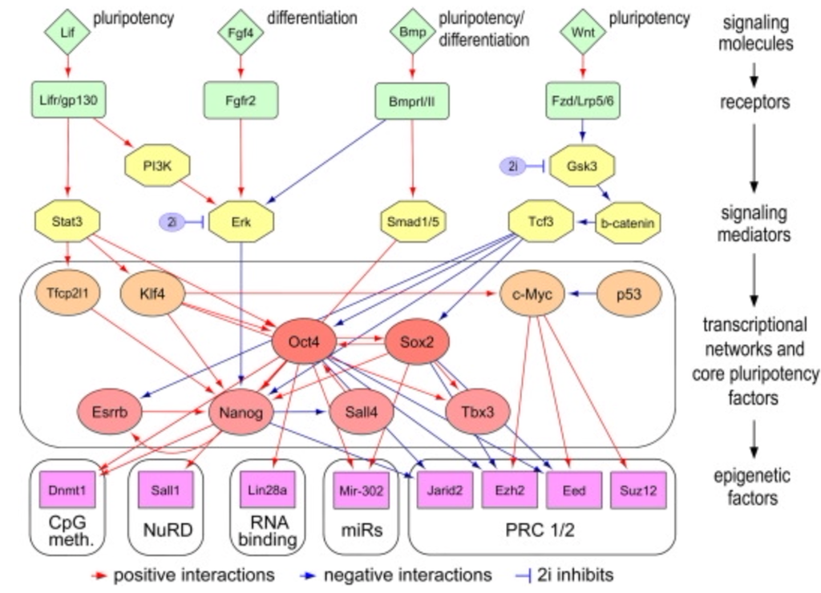

Figure 2.10: Transcription factor regulation over differentiation and self-renewal periods. Source: Papatsenko, Waghray, and Lemischka (2018).

Moreover, our results indicated that the combined transcriptome/proteome dataset performed the best compared to the epigenome datasets, which may be attributed to the differences in the role transcription factors play in transcriptional and epigenetic regulation of stem cell gene expression. This highlights a series of challenges relating to determining how the interactions between epigenomic features and transcription factors correspond to maintaining pluripotency (Atlasi and Stunnenberg 2017). One such challenge is the fact that transcription factors can interact with DNA methyltransferases to promote site-specific DNA methylation and histone modification to maintain stem cell pluripotency, rather than the transcription factor directly binding to the target gene (Gibney and Nolan 2010). Thus, our models can be further developed by accounting for missing or unknown data, such as the interplay between the transcription factors and epigenomic dynamics, which may be corrected by gene expression and sequencing technologies as they become more advanced.

[session information not shown]

# References

Atlasi, Yaser, and Hendrik G. Stunnenberg. 2017. “The Interplay of Epigenetic Marks During Stem Cell Differentiation and Development.” *Nature Reviews Genetics* 18 (11): 643–58. https://doi.org/10.1038/nrg.2017.57.

Gibney, Eileen R., and Catherine M. Nolan. 2010. “Epigenetics and Gene Expression.” *Heredity* 105 (1): 4–13. https://doi.org/10.1038/hdy.2010.54.

Papatsenko, Dmitri, Avinash Waghray, and Ihor R. Lemischka. 2018. “Feedback Control of Pluripotency in Embryonic Stem Cells: Signaling, Transcription and Epigenetics.” *Stem Cell Research* 29: 180–88. https://doi.org/https://doi.org/10.1016/j.scr.2018.02.012.

Richards, Mark, Siew-Peng Tan, Jee-Hian Tan, Woon-Khiong Chan, and Ariff Bongso. 2004. “The Transcriptome Profile of Human Embryonic Stem Cells as Defined by SAGE.” *Stem Cells (Dayton, Ohio)* 22 (1): 51–64. https://doi.org/10.1634/stemcells.22-1-51.

Theunissen, Thorold W., and Rudolf Jaenisch. 2017. “Mechanisms of Gene Regulation in Human Embryos and Pluripotent Stem Cells.” *Development (Cambridge, England)* 144 (24): 4496–4509. https://doi.org/10.1242/dev.157404.